# LC-MS data pre-processing and analysis with xcms

16 January 2024

#### Package

xcms 4.0.2

**Package**: *xcms*  
**Authors**: Johannes Rainer  
**Modified**: 2023-12-05 14:05:23.491522  
**Compiled**: Tue Jan 16 22:59:47 2024

# 1 Introduction

The *xcms* package provides the functionality to perform the pre-processing of LC-MS, GC-MS or LC-MS/MS data in which raw signals from mzML, mzXML or CDF files are processed into *feature* abundances. This pre-processing includes chromatographic peak detection, sample alignment and correspondence analysis.

The first version of the package was already published in 2006 [1] and has since been updated and modernized in several rounds to better integrate it with other R-based packages for the analysis of untargeted metabolomics data. This includes version 3 of *xcms* that used the *MSnbase* package for MS data representation [2]. The most recent update (*xcms* version 4) enables in addition pre-processing of MS data represented by the modern *MsExperiment* and *Spectra* packages which provides an even better integration with the [RforMassSpectrometry](https://rformassspectrometry.org) R package ecosystem simplifying e.g. also compound annotation [3].

This document describes data import, exploration and pre-processing of a simple test LC-MS data set with the *xcms* package version >= 4. The same functions can be applied to the older *MSnbase*-based workflows (xcms version 3). Additional documents and tutorials covering also other topics of untargeted metabolomics analysis are listed at the end of this document.

# 2 Pre-processing of LC-MS data

## 2.1 Data import

*xcms* supports analysis of any LC-MS(/MS) data that can be imported with the *Spectra* package. Such data will typically be provided in (AIA/ANDI) NetCDF, mzXML and mzML format but can, through dedicated extensions to the *Spectra* package, also be imported from other sources, e.g. also directly from raw data files in manufacturer’s formats.

For demonstration purpose we will analyze in this document a small subset of the data from [4] in which the metabolic consequences of the knock-out of the fatty acid amide hydrolase (FAAH) gene in mice was investigated. The raw data files (in NetCDF format) are provided through the *faahKO* data package. The data set consists of samples from the spinal cords of 6 knock-out and 6 wild-type mice. Each file contains data in centroid mode acquired in positive ion polarity from 200-600 m/z and 2500-4500 seconds. To speed-up processing of this vignette we will restrict the analysis to only 8 files.

Below we load all required packages, locate the raw CDF files within the *faahKO* package and build a *phenodata* `data.frame` describing the experimental setup. Generally, such data frames should contain all relevant experimental variables and sample descriptions (including also the names of the raw data files) and will be imported into R using either the `read.table` function (if the file is in *csv* or tabulator delimited text file format) or also using functions from the *readxl* R package if it is in Excel file format.

```r
library(xcms)
library(faahKO)
library(RColorBrewer)
library(pander)
library(pheatmap)
library(MsExperiment)

## Get the full path to the CDF files
cdfs <- dir(system.file("cdf", package = "faahKO"), full.names = TRUE,
            recursive = TRUE)[c(1, 2, 5, 6, 7, 8, 11, 12)]
## Create a phenodata data.frame
pd <- data.frame(sample_name = sub(basename(cdfs), pattern = ".CDF",
                                   replacement = "", fixed = TRUE),
                 sample_group = c(rep("KO", 4), rep("WT", 4)),
                 stringsAsFactors = FALSE)
```

We next load our data using the `readMsExperiment` function from the *MsExperiment* package.

```r
faahko <- readMsExperiment(spectraFiles = cdfs, sampleData = pd)
faahko
```

```
## Object of class MsExperiment
##  Spectra: MS1 (10224)
##  Experiment data: 8 sample(s)
##  Sample data links:
##   - spectra: 8 sample(s) to 10224 element(s).
```

The MS spectra data from our experiment is now available as a `Spectra` object within `faahko`. Note that this `MsExperiment` container could in addition to spectra data also contain other types of data or also references to other files. See the vignette from the *MsExperiment* for more details. Also, when loading data from mzML, mzXML or CDF files, by default only general spectra data is loaded into memory while the actual *peaks data*, i.e. the m/z and intensity values are only retrieved on-the-fly from the raw files when needed (this is similar to the *MSnbase* *on-disk* mode described in [2]). This guarantees a low memory footprint hence allowing to analyze also large experiments without the need of high performance computing environments. Note that also different alternative *backends* (and hence data representations) could be used for the `Spectra` object within `faahko` with eventually even lower memory footprint, or higher performance. See the package vignette from the *Spectra* package or the SpectraTutorials tutorial for more details on `Spectra` backends and how to change between them.

## 2.2 Initial data inspection

The `MsExperiment` object is a simple and flexible container for MS experiments. The *raw* MS data is stored as a `Spectra` object that can be accessed through the `spectra` function.

```r
spectra(faahko)
```

```
## MSn data (Spectra) with 10224 spectra in a MsBackendMzR backend:
##         msLevel     rtime scanIndex
##       <integer> <numeric> <integer>
## 1             1   2501.38         1
## 2             1   2502.94         2
## 3             1   2504.51         3
## 4             1   2506.07         4
## 5             1   2507.64         5
## ...         ...       ...       ...
## 10220         1   4493.56      1274
## 10221         1   4495.13      1275
## 10222         1   4496.69      1276
## 10223         1   4498.26      1277
## 10224         1   4499.82      1278
##  ... 33 more variables/columns.
##
## file(s):
## ko15.CDF
## ko16.CDF
## ko21.CDF
##  ... 5 more files
```

All spectra are organized *sequentially* (i.e., not by file) but the `fromFile` function can be used to get for each spectrum the information to which of the data files it belongs. Below we simply count the number of spectra per file.

```r
table(fromFile(faahko))
```

```
##
##    1    2    3    4    5    6    7    8
## 1278 1278 1278 1278 1278 1278 1278 1278
```

Information on samples can be retrieved through the `sampleData` function.

```r
sampleData(faahko)
```

```
## DataFrame with 8 rows and 3 columns
##   sample_name sample_group  spectraOrigin
##   <character>  <character>    <character>
## 1        ko15           KO F:\\biocbui...
## 2        ko16           KO F:\\biocbui...
## 3        ko21           KO F:\\biocbui...
## 4        ko22           KO F:\\biocbui...
## 5        wt15           WT F:\\biocbui...
## 6        wt16           WT F:\\biocbui...
## 7        wt21           WT F:\\biocbui...
## 8        wt22           WT F:\\biocbui...
```

Each row in this `DataFrame` represents one sample (input file). Using `[` it is possible to subset a `MsExperiment` object **by sample**. Below we subset the `faahko` to the 3rd sample (file) and access its spectra and sample data.

```r
faahko_3 <- faahko[3]
spectra(faahko_3)
```

```
## MSn data (Spectra) with 1278 spectra in a MsBackendMzR backend:
##        msLevel     rtime scanIndex
##      <integer> <numeric> <integer>
## 1            1   2501.38         1
## 2            1   2502.94         2
## 3            1   2504.51         3
## 4            1   2506.07         4
## 5            1   2507.64         5
## ...        ...       ...       ...
## 1274         1   4493.56      1274
## 1275         1   4495.13      1275
## 1276         1   4496.69      1276
## 1277         1   4498.26      1277
## 1278         1   4499.82      1278
##  ... 33 more variables/columns.
##
## file(s):
## ko21.CDF
```

```r
sampleData(faahko_3)
```

```
## DataFrame with 1 row and 3 columns
##   sample_name sample_group  spectraOrigin
##   <character>  <character>    <character>
## 1        ko21           KO F:\\biocbui...
```

As a first evaluation of the data we below plot the base peak chromatogram (BPC) for each file in our experiment. We use the `chromatogram` method and set the `aggregationFun` to `"max"` to return for each spectrum the maximal intensity and hence create the BPC from the raw data. To create a total ion chromatogram we could set `aggregationFun` to `"sum"`.

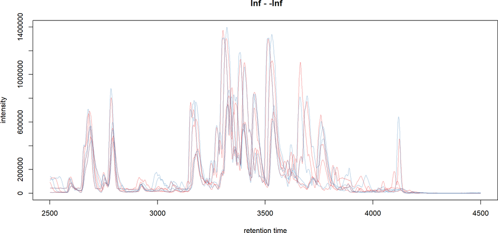

Figure 1: Base peak chromatogram

```r
## Get the base peak chromatograms. This reads data from the files.
bpis <- chromatogram(faahko, aggregationFun = "max")
## Define colors for the two groups
group_colors <- paste0(brewer.pal(3, "Set1")[1:2], "60")
names(group_colors) <- c("KO", "WT")

## Plot all chromatograms.
plot(bpis, col = group_colors[sampleData(faahko)$sample_group])
```

The `chromatogram` method returned a `MChromatograms` object that organizes individual `Chromatogram` objects (which in fact contain the chromatographic data) in a two-dimensional array: columns represent samples and rows (optionally) m/z and/or retention time ranges. Below we extract the chromatogram of the first sample and access its retention time and intensity values.

```r
bpi_1 <- bpis[1, 1]
rtime(bpi_1) |> head()
```

```
## [1] 2501.378 2502.943 2504.508 2506.073 2507.638 2509.203
```

```r
intensity(bpi_1) |> head()
```

```
## [1] 43888 43960 43392 42632 42200 42288
```

From the BPC above it seems that after around 4200 seconds no signal is measured anymore. Thus, we filter below the full data set to a retention time range from 2550 to 4250 seconds using the `filterRt` function. Note that at present this will only subset the spectra within the `MsExperiment`. Subsequently we re-create also the BPC.

```r
faahko <- filterRt(faahko, rt = c(2550, 4250))
```

```
## Filter spectra
```

```r
## creating the BPC on the subsetted data
bpis <- chromatogram(faahko, aggregationFun = "max")
```

We next create boxplots representing the distribution of the total ion currents per data file. Such plots can be very useful to spot potentially problematic MS runs. To extract this information, we use the `tic` function on the `Spectra` object within `faahko` and split the values by file using `fromFile`.

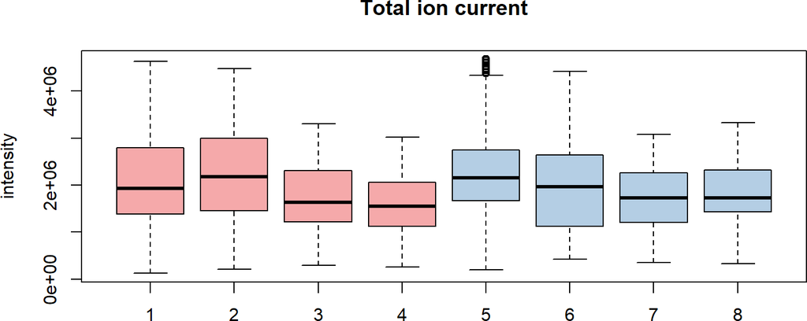

Figure 2: Distribution of total ion currents per file

```r
## Get the total ion current by file
tc <- spectra(faahko) |>
    tic() |>
    split(f = fromFile(faahko))
boxplot(tc, col = group_colors[sampleData(faahko)$sample_group],
        ylab = "intensity", main = "Total ion current")
```

In addition, we can also cluster the samples based on similarity of their base peak chromatograms. Samples would thus be grouped based on similarity of their LC runs. For that we need however to *bin* the data along the retention time axis, since retention times will generally differ between samples. Below we use the `bin` function on the BPC to bin intensities into 2 second wide retention time bins. The clustering is then performed using complete linkage hierarchical clustering on the pairwise correlations of the binned base peak chromatograms.

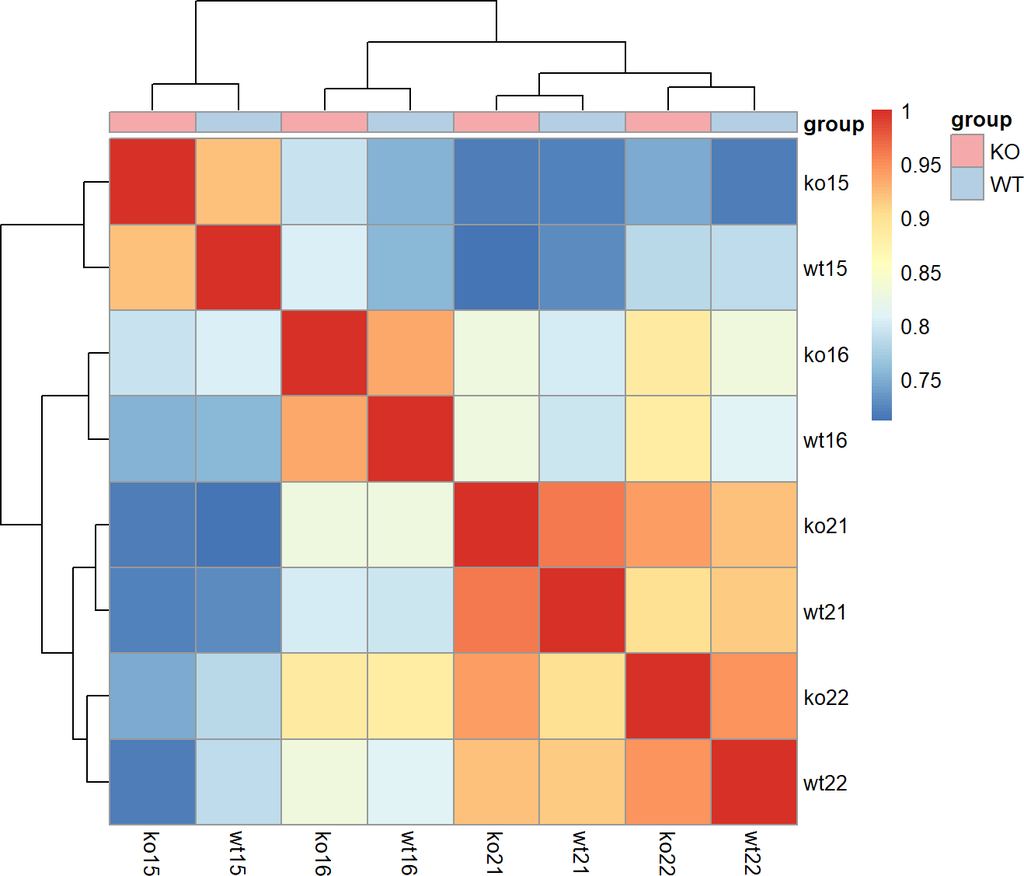

Figure 3: Grouping of samples based on similarity of their base peak chromatogram

```r
## Bin the BPC
bpis_bin <- bin(bpis, binSize = 2)

## Calculate correlation on the log2 transformed base peak intensities
cormat <- cor(log2(do.call(cbind, lapply(bpis_bin, intensity))))
colnames(cormat) <- rownames(cormat) <- bpis_bin$sample_name

## Define which phenodata columns should be highlighted in the plot
ann <- data.frame(group = bpis_bin$sample_group)
rownames(ann) <- bpis_bin$sample_name

## Perform the cluster analysis
pheatmap(cormat, annotation = ann,
         annotation_color = list(group = group_colors))
```

The samples cluster in a pairwise manner, with the KO and WT samples for the same sample index having the most similar BPC.

## 2.3 Chromatographic peak detection

Chromatographic peak detection aims at identifying all signal in each sample created from ions of the same originating compound species. Chromatographic peak detection can be performed in *xcms* with the `findChromPeaks` function and a *parameter* object which defines and configures the algorithm that should be used (see `?findChromPeaks` for a list of supported algorithms). Before running any peak detection it is however strongly suggested to first visually inspect the extracted ion chromatogram of e.g. internal standards or compounds known to be present in the samples in order to evaluate and adapt the settings of the peak detection algorithm since the default settings will not be appropriate for most LC-MS setups.

Below we extract the EIC for one compound using the `chromatogram` function by specifying in addition the m/z and retention time range where we would expect the signal for that compound.

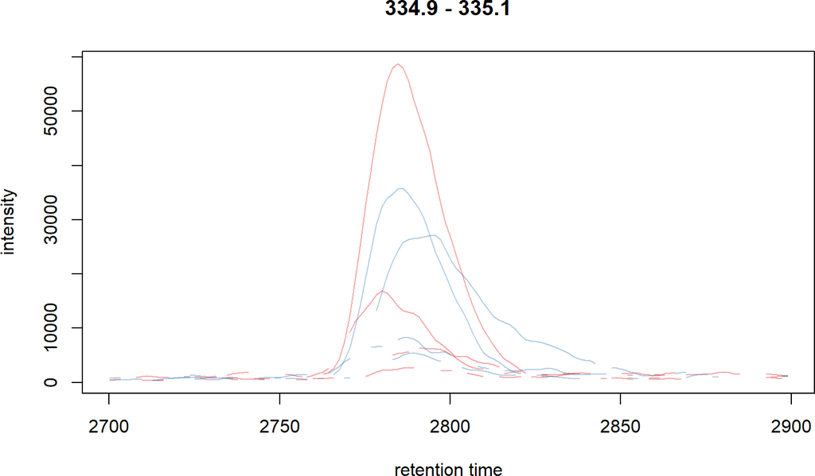

Figure 4: Extracted ion chromatogram for one peak

```r
## Define the rt and m/z range of the peak area
rtr <- c(2700, 2900)
mzr <- c(334.9, 335.1)
## extract the chromatogram
chr_raw <- chromatogram(faahko, mz = mzr, rt = rtr)
plot(chr_raw, col = group_colors[chr_raw$sample_group])
```

Note that `Chromatogram` objects extracted by the `chromatogram` method contain an `NA` value if in a certain scan (i.e. in a spectrum for a specific retention time) no signal was measured in the respective m/z range. This is reflected by the lines not being drawn as continuous lines in the plot above.

The peak above has thus a width of about 50 seconds. We can use this information to define the `peakwidth` parameter of the *centWave* peak detection method [5] that we will use for chromatographic peak detection on our data. The `peakwidth` parameter allows to define the expected lower and upper width (in retention time dimension) of chromatographic peaks. For our data we set it thus to `peakwidth = c(20, 80)`. The second important parameter for *centWave* is `ppm` which defines the expected maximum deviation of m/z values of the centroids that should be included into one chromatographic peak (note that this is **not** the precision of m/z values provided by the MS instrument manufacturer).

For the `ppm` parameter we extract the full MS data (intensity, retention time and m/z values) corresponding to the above peak. To this end we first filter the raw object by retention time, then by m/z and finally plot the object with `type = "XIC"` to produce the plot below. We use the *pipe* (`|>`) operator to better illustrate the corresponding workflow.

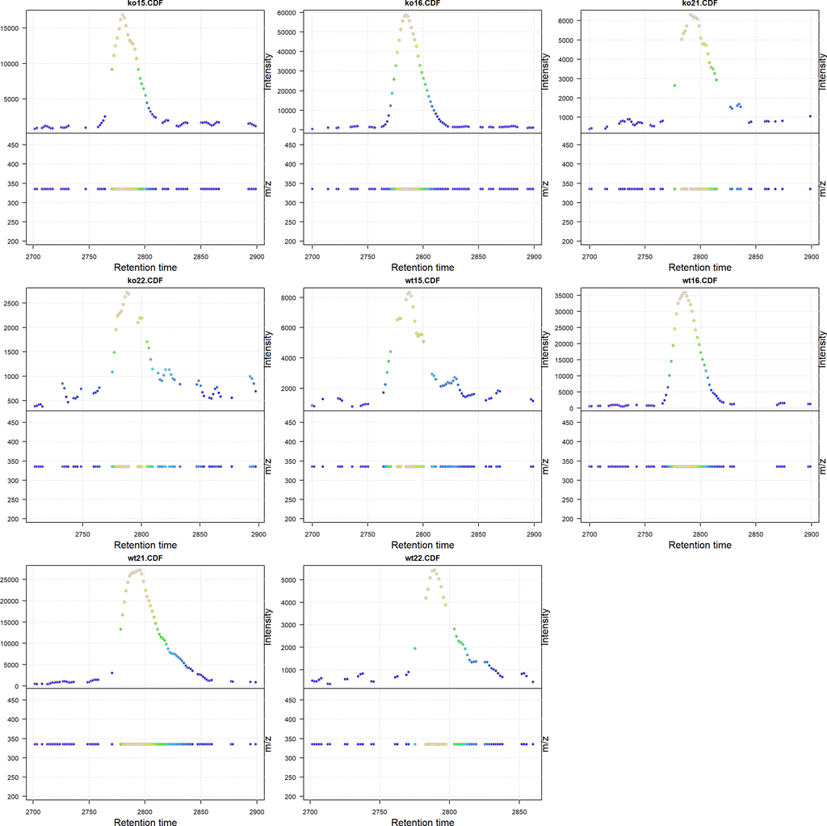

Figure 5: Visualization of the raw MS data for one peak  
For each plot: upper panel: chromatogram plotting the intensity values against the retention time, lower panel m/z against retention time plot. The individual data points are colored according to the intensity.

```r
faahko |>
filterRt(rt = rtr) |>
filterMz(mz = mzr) |>
plot(type = "XIC")
```

In the present data there is actually no variation in the m/z values. Usually the m/z values of the individual centroids (lower panel) in the plots above would scatter around the *real* m/z value of the compound (in an intensity dependent manner).

The first step of the *centWave* algorithm defines *regions of interest* (ROI) that are subsequently screened for the presence of chromatographic peaks. These ROIs are defined based on the difference of m/z values of centroids from consecutive scans (spectra). In detail, centroids from consecutive scans are included into a ROI if the difference between their m/z and the mean m/z of the ROI is smaller than the user defined `ppm` parameter. A reasonable choice for the `ppm` could thus be the maximal m/z difference of data points from neighboring scans/spectra that are part of a chromatographic peak for an internal standard of known compound. It is suggested to inspect the ranges of m/z values for several compounds (either internal standards or compounds known to be present in the sample) and define the `ppm` parameter for *centWave* according to these. See also this [tutorial](https://jorainer.github.io/metabolomics2018) for additional information and examples on choosing and testing peak detection settings.

Chromatographic peak detection can also be performed on extracted ion chromatograms, which helps testing and tuning peak detection settings. Note however that peak detection on EICs does not involve the first step of *centWave* described above and will thus **not** consider the `ppm` parameter. Also, since less data is available to the algorithms, background signal estimation is performed differently and different settings for `snthresh` will need to be used (generally a lower `snthresh` will be used for EICs since the estimated background signal tends to be higher for data subsets than for the full data). Below we perform the peak detection with the `findChromPeaks` function on the EIC generated above. The submitted *parameter* object defines which algorithm will be used and allows to define the settings for this algorithm. We use a `CentWaveParam` parameter object to use and configure the *centWave* algorithm with default settings, except for `snthresh`.

```r
xchr <- findChromPeaks(chr_raw, param = CentWaveParam(snthresh = 2))
```

We can access the identified chromatographic peaks with the `chromPeaks` function.

```r
chromPeaks(xchr)
```

```
##             rt    rtmin    rtmax        into        intb  maxo   sn row column
##  [1,] 2781.505 2761.160 2809.674  412134.255  355516.374 16856   13   1      1
##  [2,] 2786.199 2764.290 2812.803 1496244.206 1391821.332 58736   20   1      2
##  [3,] 2734.556 2714.211 2765.855   21579.367   18449.428   899    4   1      3
##  [4,] 2797.154 2775.245 2815.933  159058.782  150289.314  6295   12   1      3
##  [5,] 2784.635 2761.160 2808.109   54947.545   37923.532  2715    2   1      4
##  [6,] 2859.752 2845.668 2878.532   13895.212   13874.868   905  904   1      4
##  [7,] 2897.311 2891.051 2898.876    5457.155    5450.895   995  994   1      4
##  [8,] 2819.064 2808.109 2834.713   19456.914   19438.134  1347 1576   1      4
##  [9,] 2789.329 2762.725 2808.109  174473.311   91114.975  8325    3   1      5
## [10,] 2786.199 2764.290 2812.803  932645.211  569236.246 35856    2   1      6
## [11,] 2792.461 2768.987 2823.760  876585.527  511324.134 27200    2   1      7
## [12,] 2789.329 2773.680 2806.544   89582.569   73871.386  5427    6   1      8
```

Parallel to the `chromPeaks` matrix there is also a `chromPeakData` data frame that allows to add arbitrary annotations to each chromatographic peak, such as e.g. the MS level in which the peak was detected:

```r
chromPeakData(xchr)
```

```
## DataFrame with 12 rows and 4 columns
##      ms_level is_filled       row    column
##     <integer> <logical> <integer> <integer>
## 1           1     FALSE         1         1
## 2           1     FALSE         1         2
## 3           1     FALSE         1         3
## 4           1     FALSE         1         3
## 5           1     FALSE         1         4
## ...       ...       ...       ...       ...
## 8           1     FALSE         1         4
## 9           1     FALSE         1         5
## 10          1     FALSE         1         6
## 11          1     FALSE         1         7
## 12          1     FALSE         1         8
```

Below we plot the EIC along with all identified chromatographic peaks using the `plot` function on the result object from above. Additional parameters `peakCol` and `peakBg` allow to define a foreground and background (fill) color for each identified chromatographic peak in the provided result object (i.e., we need to define one color for each row of `chromPeaks(xchr)` - column `"column"` (or `"sample"` if present) in that peak matrix specifies the sample in which the peak was identified).

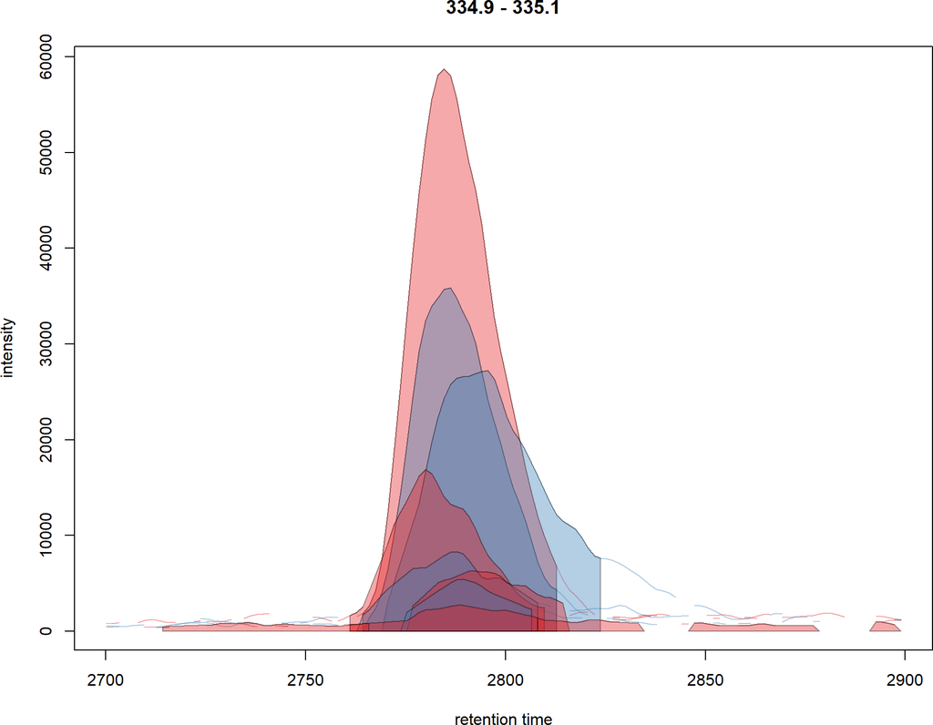

Figure 6: Signal for an example peak  
Red and blue colors represent KO and wild type samples, respectively. Peak area of identified chromatographic peaks are highlighted in the sample group color.

```r
## Define a color for each sample
sample_colors <- group_colors[xchr$sample_group]
## Define the background color for each chromatographic peak
bg <- sample_colors[chromPeaks(xchr)[, "column"]]
## Parameter `col` defines the color of each sample/line, `peakBg` of each
## chromatographic peak.
plot(xchr, col = sample_colors, peakBg = bg)
```

If we are happy with the settings we can use them for the peak detection on the full data set (i.e. on the `MsExperiment` object with the data for the whole experiment). Note that below we set the argument `prefilter` to `c(6, 5000)` and `noise` to `5000` to reduce the run time of this vignette. With this setting we consider only ROIs with at least 6 centroids with an intensity larger than 5000 for the *centWave* chromatographic peak detection.

```r
cwp <- CentWaveParam(peakwidth = c(20, 80), noise = 5000,
                     prefilter = c(6, 5000))
faahko <- findChromPeaks(faahko, param = cwp)
```

The results of `findChromPeaks` on a `MsExperiment` object are returned as an `XcmsExperiment` object. This object extends `MsExperiment` directly (hence providing the same access to all raw data) and contains all *xcms* pre-processing results. Note also that additional rounds of chromatographic peak detections could be performed and their results being added to existing peak detection results by additional calls to `findChromPeaks` on the result object and using parameter `add = TRUE`.

The `chromPeaks` function can also here be used to access the results from the chromatographic peak detection. Below we show the first 6 identified chromatographic peaks.

```r
chromPeaks(faahko) |> head()
```

```
##           mz mzmin mzmax       rt    rtmin    rtmax     into     intb  maxo sn
## CP0001 594.0 594.0 594.0 2601.535 2581.191 2637.529 161042.2 146073.3  7850 11
## CP0002 577.0 577.0 577.0 2604.665 2581.191 2626.574 136105.2 128067.9  6215 11
## CP0003 307.0 307.0 307.0 2618.750 2592.145 2645.354 284782.4 264907.0 16872 20
## CP0004 302.0 302.0 302.0 2617.185 2595.275 2640.659 687146.6 669778.1 30552 43
## CP0005 370.1 370.1 370.1 2673.523 2643.789 2700.127 449284.6 417225.3 25672 17
## CP0006 427.0 427.0 427.0 2675.088 2643.789 2684.478 283334.7 263943.2 11025 13
##        sample
## CP0001      1
## CP0002      1
## CP0003      1
## CP0004      1
## CP0005      1
## CP0006      1
```

Columns of this `chromPeaks` matrix might differ depending on the used peak detection algorithm. Columns that all algorithms have to provide are: `"mz"`, `"mzmin"`, `"mzmax"`, `"rt"`, `"rtmin"` and `"rtmax"` that define the m/z and retention time range of the chromatographic peak (i.e. all mass peaks within that area are used to integrate the peak signal) as well as the m/z and retention time of the peak apex. Other mandatory columns are `"into"` and `"maxo"` with the absolute integrated peak signal and the maximum peak intensity. Finally, `"sample"` provides the index of the sample in which the peak was identified.

Additional annotations for each individual peak can be extracted with the `chromPeakData` function. This data frame could also be used to add/store arbitrary annotations for each detected peak (that don’t necessarily need to be numeric).

```r
chromPeakData(faahko)
```

```
## DataFrame with 2908 rows and 2 columns
##         ms_level is_filled
##        <integer> <logical>
## CP0001         1     FALSE
## CP0002         1     FALSE
## CP0003         1     FALSE
## CP0004         1     FALSE
## CP0005         1     FALSE
## ...          ...       ...
## CP2904         1     FALSE
## CP2905         1     FALSE
## CP2906         1     FALSE
## CP2907         1     FALSE
## CP2908         1     FALSE
```

Peak detection will not always work perfectly for all types of peak shapes present in the data set leading to peak detection artifacts, such as (partially or completely) overlapping peaks or artificially split peaks (common issues especially for *centWave*). *xcms* provides the `refineChromPeaks` function that can be called on peak detection results in order to *refine* (or clean) peak detection results by either removing identified peaks not passing a certain criteria or by merging artificially split or partially or completely overlapping chromatographic peaks. Different algorithms are available that can again be configured with their respective parameter objects: `CleanPeaksParam` and `FilterIntensityParam` allow to remove peaks with their retention time range or intensity being below a specified threshold, respectively. With `MergeNeighboringPeaksParam` it is possible to merge chromatographic peaks and hence remove many of the above mentioned (*centWave*) peak detection artifacts. See also `?refineChromPeaks` for more information and help on the different methods.

Below we post-process the peak detection results merging peaks that overlap in a 4 second window per file and for which the signal between them is lower than 75% of the smaller peak’s maximal intensity. See the `?MergeNeighboringPeaksParam` help page for a detailed description of the settings and the approach.

```r
mpp <- MergeNeighboringPeaksParam(expandRt = 4)
faahko_pp <- refineChromPeaks(faahko, mpp)
```

An example for a merged peak is given below.

```r
mzr_1 <- 305.1 + c(-0.01, 0.01)
chr_1 <- chromatogram(faahko[1], mz = mzr_1)
```

```
## Processing chromatographic peaks
```

```r
chr_2 <- chromatogram(faahko_pp[1], mz = mzr_1)
```

```
## Processing chromatographic peaks
```

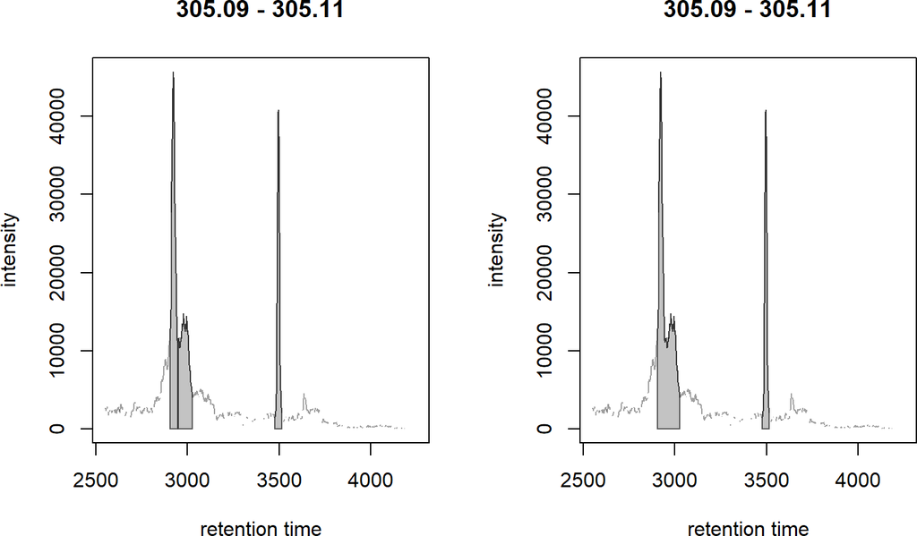

Figure 7: Result from the peak refinement step  
Left: data before processing, right: after refinement. The splitted peak was merged into one.

```r
par(mfrow = c(1, 2))
plot(chr_1)
plot(chr_2)
```

*centWave* thus detected originally 3 chromatographic peaks in the m/z slice (left panel in the plot above) and peak refinement with `MergeNeighboringPeaksParam` and the specified settings merged the first two peaks into a single one (right panel in the figure above). Other close peaks, with a lower intensity between them, were however not merged (see below).

```r
mzr_1 <- 496.2 + c(-0.01, 0.01)
chr_1 <- chromatogram(faahko[1], mz = mzr_1)
```

```
## Processing chromatographic peaks
```

```r
chr_2 <- chromatogram(faahko_pp[1], mz = mzr_1)
```

```
## Processing chromatographic peaks
```

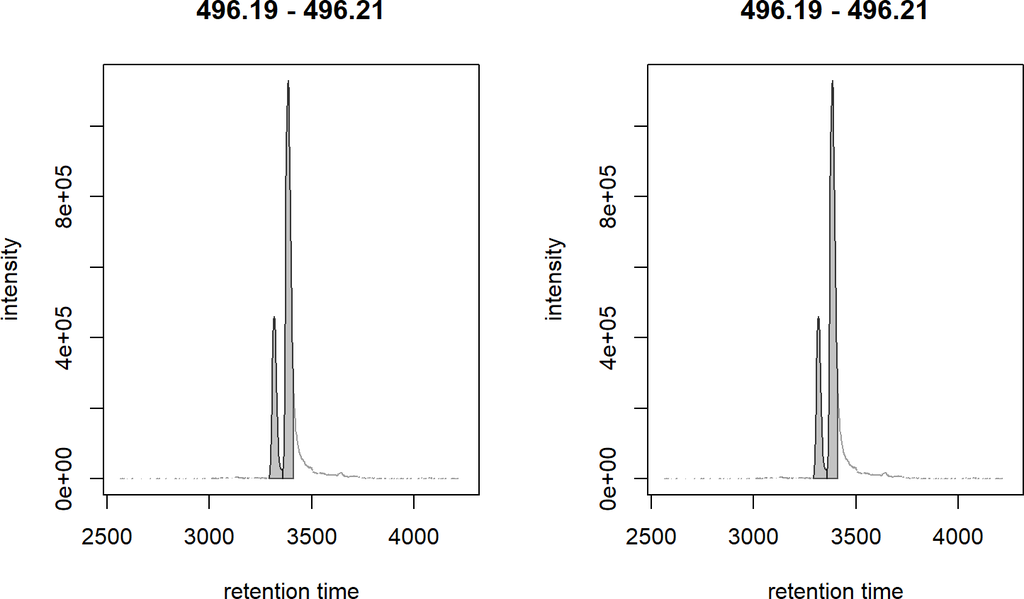

Figure 8: Result from the peak refinement step  
Left: data before processing, right: after refinement. The peaks were not merged.

```r
par(mfrow = c(1, 2))
plot(chr_1)
plot(chr_2)
```

It is also possible to perform the peak refinement on extracted ion chromatograms. This could again be used to test and fine-tune the settings for the parameter. To illustrate this we perform below a peak refinement on the extracted ion chromatogram `chr_1` reducing the `minProp` parameter to force joining the two peaks.

```r
res <- refineChromPeaks(chr_1, MergeNeighboringPeaksParam(minProp = 0.05))
chromPeaks(res)
```

```
##         mz  mzmin  mzmax       rt    rtmin    rtmax     into intb    maxo  sn
## CPM1 496.2 496.19 496.21 3384.012 3294.809 3412.181 45940118   NA 1128960 177
##      sample row column
## CPM1      1   1      1
```

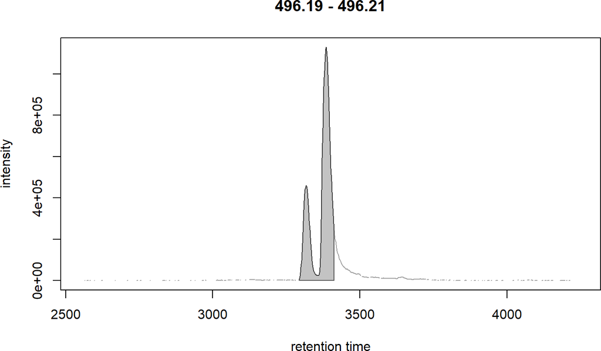

```r
plot(res)
```

Before proceeding we next replace the `faahko` object with the results from the peak refinement step.

```r
faahko <- faahko_pp
```

Below we use the data from the `chromPeaks` matrix to calculate per-file summaries of the peak detection results, such as the number of peaks per file as well as the distribution of the retention time widths.

```r
summary_fun <- function(z)
    c(peak_count = nrow(z), rt = quantile(z[, "rtmax"] - z[, "rtmin"]))

T <- chromPeaks(faahko) |>
    split.data.frame(f = chromPeaks(faahko)[, "sample"]) |>
    lapply(FUN = summary_fun) |>
    do.call(what = rbind)
rownames(T) <- basename(fileNames(faahko))
pandoc.table(
    T,
    caption = paste0("Summary statistics on identified chromatographic",
                     " peaks. Shown are number of identified peaks per",
                     " sample and widths/duration of chromatographic ",
                     "peaks."))
```

Summary statistics on identified chromatographic peaks. Shown are number of identified peaks per sample and widths/duration of chromatographic peaks.

|  | peak_count | rt.0% | rt.25% | rt.50% | rt.75% | rt.100% |
| --- | --- | --- | --- | --- | --- | --- |
| **ko15.CDF** | 397 | 10.95 | 34.43 | 42.25 | 53.21 | 319.2 |
| **ko16.CDF** | 520 | 10.95 | 32.86 | 42.25 | 53.21 | 151.8 |
| **ko21.CDF** | 207 | 10.95 | 42.25 | 50.08 | 65.73 | 164.3 |
| **ko22.CDF** | 233 | 10.95 | 37.56 | 46.95 | 59.47 | 147.1 |
| **wt15.CDF** | 403 | 10.95 | 32.86 | 42.25 | 53.21 | 161.2 |
| **wt16.CDF** | 361 | 10.95 | 35.99 | 45.38 | 57.9 | 162.8 |
| **wt21.CDF** | 227 | 10.95 | 35.21 | 48.51 | 64.16 | 172.1 |
| **wt22.CDF** | 328 | 10.95 | 35.99 | 45.38 | 57.9 | 228.5 |

While by default `chromPeaks` will return all identified chromatographic peaks in a result object it is also possible to extract only chromatographic peaks for a specified m/z and/or rt range:

```r
chromPeaks(faahko, mz = c(334.9, 335.1), rt = c(2700, 2900))
```

```
##         mz mzmin mzmax       rt    rtmin    rtmax      into      intb  maxo sn
## CP0038 335   335   335 2781.505 2761.160 2809.674  412134.3  383167.4 16856 23
## CP0494 335   335   335 2786.199 2764.290 2812.803 1496244.2 1461187.3 58736 72
## CP1025 335   335   335 2797.154 2775.245 2815.933  159058.8  149229.6  6295 13
## CP1964 335   335   335 2786.199 2764.290 2812.803  932645.2  915333.8 35856 66
## CP2349 335   335   335 2792.461 2768.987 2823.760  876585.5  848569.1 27200 36
##        sample
## CP0038      1
## CP0494      2
## CP1025      3
## CP1964      6
## CP2349      7
```

We can also plot the location of the identified chromatographic peaks in the m/z - retention time space for one file using the `plotChromPeaks` function. Below we plot this information for the third sample.

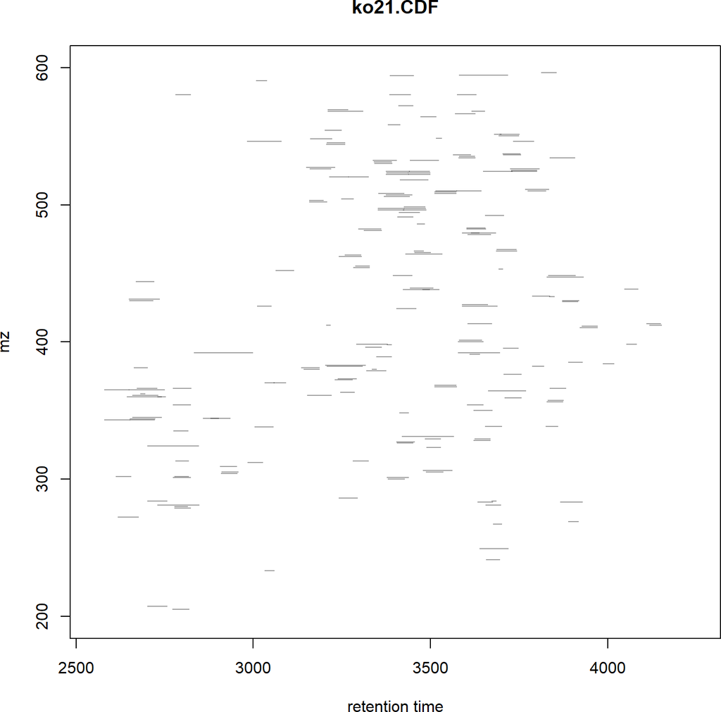

Figure 9: Identified chromatographic peaks in the m/z by retention time space for one sample

```r
plotChromPeaks(faahko, file = 3)
```

As a general overview of the peak detection results we can in addition visualize the number of identified chromatographic peaks per file along the retention time axis. Parameter `binSize` allows to define the width of the bins in rt dimension in which peaks should be counted. This number of chromatographic peaks within each bin is then shown color-coded in the resulting plot.

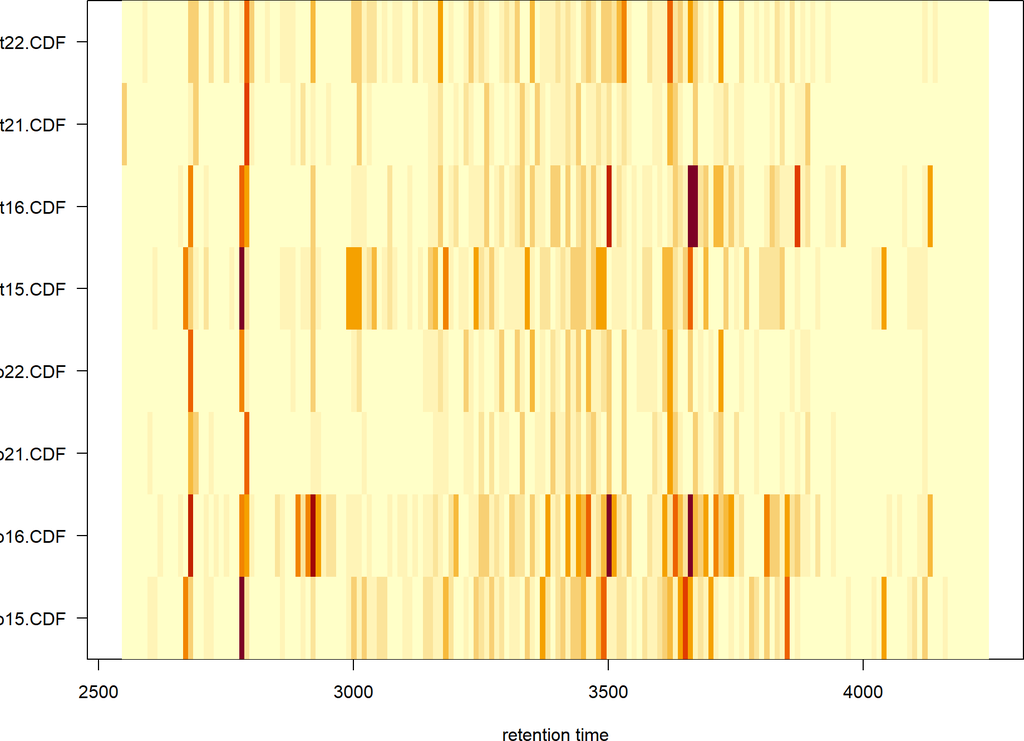

```r
plotChromPeakImage(faahko, binSize = 10)
```

Note that extracting ion chromatorams from an *xcms* result object will in addition to the chromatographic data also extract any identified chromatographic peaks within that region. This can thus also be used to validate and verify that the used peak detection settings identified e.g. peaks for known compounds or internal standards properly. Below we extract the ion chromatogram for the m/z - rt region above and access the detected peaks in that region using the `chromPeaks` function.

```r
chr_ex <- chromatogram(faahko, mz = mzr, rt = rtr)
chromPeaks(chr_ex)
```

```
##         mz mzmin mzmax       rt    rtmin    rtmax      into      intb  maxo sn
## CP0038 335   335   335 2781.505 2761.160 2809.674  412134.3  383167.4 16856 23
## CP0494 335   335   335 2786.199 2764.290 2812.803 1496244.2 1461187.3 58736 72
## CP1025 335   335   335 2797.154 2775.245 2815.933  159058.8  149229.6  6295 13
## CP1964 335   335   335 2786.199 2764.290 2812.803  932645.2  915333.8 35856 66
## CP2349 335   335   335 2792.461 2768.987 2823.760  876585.5  848569.1 27200 36
##        sample row column
## CP0038      1   1      1
## CP0494      2   1      2
## CP1025      3   1      3
## CP1964      6   1      6
## CP2349      7   1      7
```

We can also plot this extracted ion chromatogram which will also visualize all identified chromatographic peaks in that region.

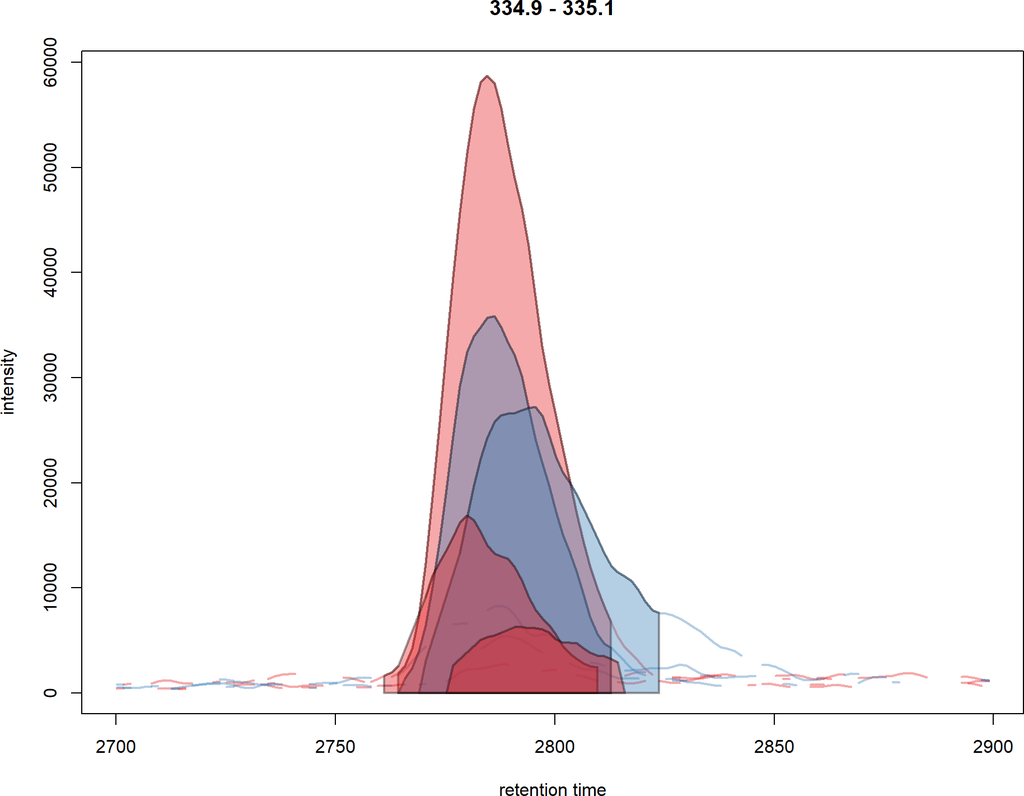

Figure 11: Signal for an example peak  
Red and blue colors represent KO and wild type samples, respectively. The signal area of identified chromatographic peaks are filled with a color.

```r
sample_colors <- group_colors[chr_ex$sample_group]
plot(chr_ex, col = group_colors[chr_raw$sample_group], lwd = 2,
     peakBg = sample_colors[chromPeaks(chr_ex)[, "sample"]])
```

Chromatographic peaks can be visualized also in other ways: by setting `peakType = "rectangle"` the they are indicated with a rectangle instead of the default highlighting option (`peakType = "polygon"`) used above. As a third alternative it would also possible to just indicate the apex position for each identified chromatographic peak with a single point (`peakType = "point"`). Below we plot the data again using `peakType = "rectangle"`.

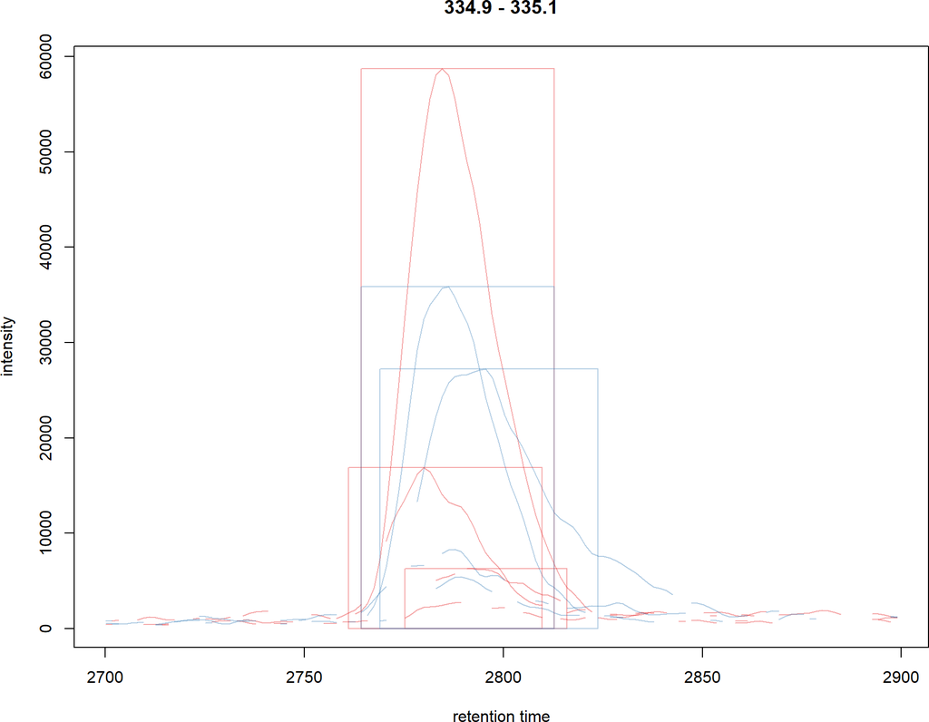

Figure 12: Signal for an example peak  
Red and blue colors represent KO and wild type samples, respectively. The rectangles indicate the identified chromatographic peaks per sample.

```r
plot(chr_ex, col = sample_colors, peakType = "rectangle",
     peakCol = sample_colors[chromPeaks(chr_ex)[, "sample"]],
     peakBg = NA)
```

Finally we plot also the distribution of peak intensity per sample. This allows to investigate whether systematic differences in peak signals between samples are present.

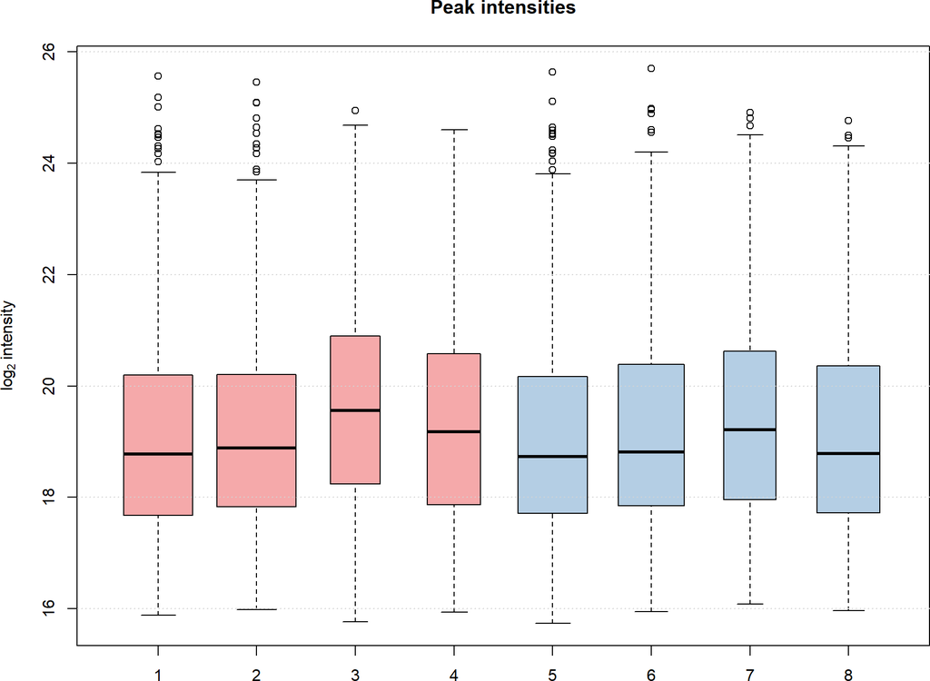

Figure 13: Peak intensity distribution per sample

```r
## Extract a list of per-sample peak intensities (in log2 scale)
ints <- split(log2(chromPeaks(faahko)[, "into"]),
              f = chromPeaks(faahko)[, "sample"])
boxplot(ints, varwidth = TRUE, col = sample_colors,
        ylab = expression(log[2]~intensity), main = "Peak intensities")
grid(nx = NA, ny = NULL)
```

Over and above the signal of the identified chromatographic peaks is comparable across samples, with the exception of samples 3, 4 and, to some degree, also 7 that show slightly higher average intensities, but also a lower number of detected peaks (indicated by the smaller width of the boxes).

Note that in addition to the above described identification of chromatographic peaks, it is also possible to *manually* define and add chromatographic peaks with the `manualChromPeaks` function (see `?manualChromPeaks` help page for more information).

## 2.4 Alignment

The time at which analytes elute in the chromatography can vary between samples (and even compounds). Such differences were already visible in the BPC and even the extracted ion chromatogram plot in the previous section. The alignment step, also referred to as retention time correction, aims to adjust these differences by shifting signals along the retention time axis and aligning them between different samples within an experiment.

A plethora of alignment algorithms exist (see [6]), with some of them being also implemented in *xcms*. Alignment of LC-MS data can be performed in *xcms* using the `adjustRtime` method and an algorithm-specific parameter class (see `?adjustRtime` for an overview of available methods in *xcms*).

In the example below we use the *obiwarp* method [7] to align the samples. We use a `binSize = 0.6` which creates warping functions in m/z bins of 0.6. Also here it is advisable to modify and adapt the settings for each experiment.

```r
faahko <- adjustRtime(faahko, param = ObiwarpParam(binSize = 0.6))
```

Note that `adjustRtime`, besides calculating adjusted retention times for each spectrum, adjusts also the retention times of the identified chromatographic peaks in the *xcms* result object. Adjusted retention times of individual spectra can be extracted from the result object using either the `adjustedRtime` function or using `rtime` with parameter `adjusted = TRUE` (the default):

```r
## Extract adjusted retention times
adjustedRtime(faahko) |> head()
```

```
## [1] 2551.457 2553.089 2554.720 2556.352 2557.983 2559.615
```

```r
## Or simply use the rtime method
rtime(faahko) |> head()
```

```
## [1] 2551.457 2553.089 2554.720 2556.352 2557.983 2559.615
```

```r
## Get raw (unadjusted) retention times
rtime(faahko, adjusted = FALSE) |> head()
```

```
## [1] 2551.457 2553.022 2554.586 2556.151 2557.716 2559.281
```

To evaluate the impact of the alignment we plot the BPC on the adjusted data. In addition we plot also the differences between the adjusted and the raw retention times per sample using the `plotAdjustedRtime` function. To disable the automatic extraction of all identified chromatographic peaks by the `chromatogram` function (which would not make much sense for a BPC) we use `chromPeaks = "none"` below.

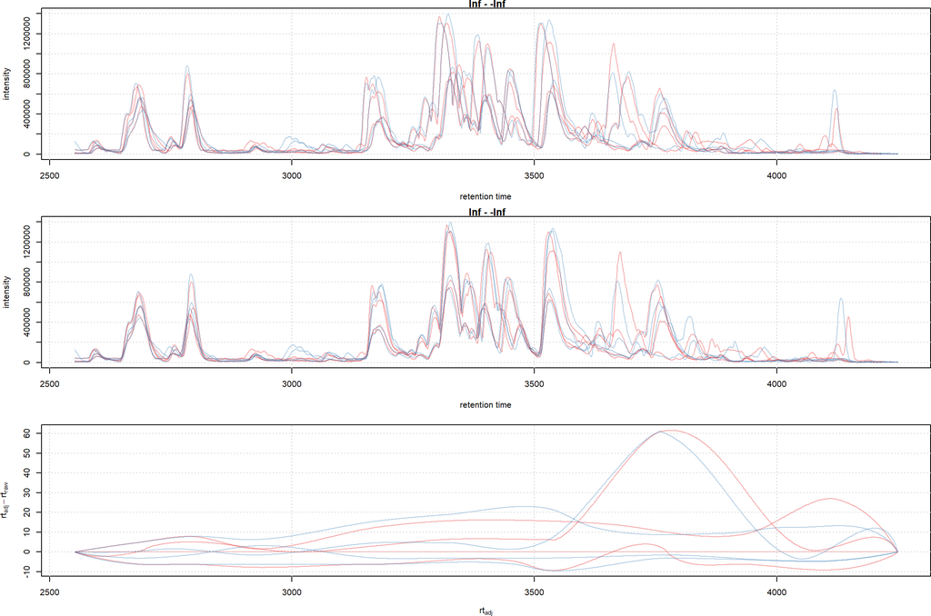

Figure 14: Obiwarp aligned data  
Base peak chromatogram before (top) and after alignment (middle) and difference between adjusted and raw retention times along the retention time axis (bottom).

```r
## Get the base peak chromatograms.
bpis_adj <- chromatogram(faahko, aggregationFun = "max", chromPeaks = "none")
par(mfrow = c(3, 1), mar = c(4.5, 4.2, 1, 0.5))
plot(bpis, col = sample_colors)
grid()
plot(bpis_adj, col = sample_colors)
grid()
## Plot also the difference of adjusted to raw retention time.
plotAdjustedRtime(faahko, col = sample_colors)
grid()
```

Too large differences between adjusted and raw retention times could indicate poorly performing samples or alignment.

At last we evaluate also the impact of the alignment on the test peak.

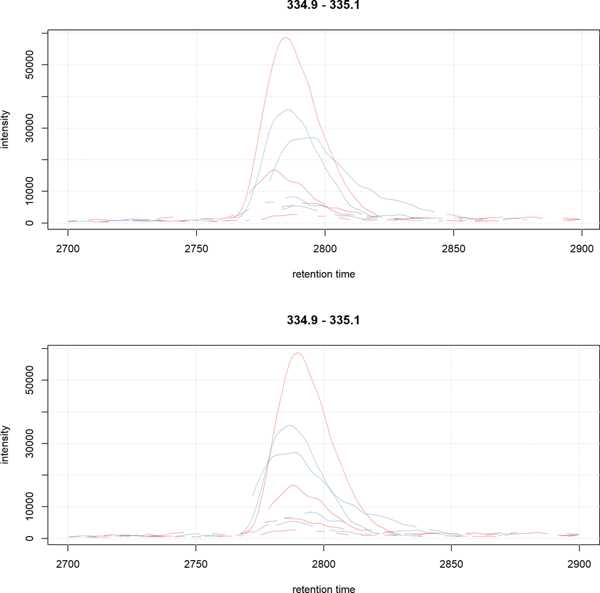

Figure 15: Example extracted ion chromatogram before (top) and after alignment (bottom)

```r
par(mfrow = c(2, 1))
## Plot the raw data
plot(chr_raw, col = sample_colors)
grid()
## Extract the chromatogram from the adjusted object
chr_adj <- chromatogram(faahko, rt = rtr, mz = mzr)
plot(chr_adj, col = sample_colors, peakType = "none")
grid()
```

**Note**: *xcms* result objects (`XcmsExperiment` as well as `XCMSnExp`) contain both the raw and the adjusted retention times for all spectra and subset operation will in many cases drop adjusted retention times. Thus it might sometimes be useful to immediately **replace** the raw retention times in the data using the `applyAdjustedRtime` function.

### 2.4.1 Subset-based alignment

For some experiments it might be better to perform the alignment based on only a subset of the available samples, e.g. if pooled QC samples were injected at regular intervals or if the experiment contains blanks. All alignment methods in *xcms* support such a subset-based alignment in which retention time shifts are estimated on only a specified subset of samples followed by an alignment of the whole data set based on the aligned subset.

The subset of samples for such an alignment can be specified with the parameter `subset` of the `PeakGroupsParam` or `ObiwarpParam` object. Parameter `subsetAdjust` allows to specify the *method* by which the *left-out* samples will be adjusted. There are currently two options available:

- `subsetAdjust = "previous"`: adjust the retention times of a non-subset sample based on the alignment results of the previous subset sample (e.g. a QC sample). If samples are e.g. in the order *A1*, *B1*, *B2*, *A2*, *B3*, *B4* with *A* representing QC samples and *B* study samples, using `subset = c(1, 4)` and `subsetAdjust = "previous"` would result in all *A* samples to be aligned with each other and non-subset samples *B1* and *B2* being adjusted based on the alignment result of subset samples *A1* and *B3* and *B4* on those of *A2*.
- `subsetAdjust = "average"`: adjust retention times of non-subset samples based on an interpolation of the alignment results of the previous and subsequent subset sample. In the example above, *B1* would be adjusted based on the average of adjusted retention times between subset (QC) samples *A1* and *A2*. Since there is no subset sample after non-subset samples *B3* and *B4* these will be adjusted based on the alignment results of *A2* alone. Note that a weighted average is used to calculate the adjusted retention time averages, which uses the inverse of the difference of the index of the non-subset sample to the subset samples as weights. Thus, if we have a setup like *A1*, *B1*, *B2*, *A2* the adjusted retention times of *A1* would get a larger weight than those of *A2* in the adjustment of non-subset sample *B1* causing it’s adjusted retention times to be closer to those of *A1* than to *A2*. See below for examples.

**Important**: both cases require a meaningful/correct ordering of the samples within the object (i.e., samples should be ordered by injection index).

The examples below aim to illustrate the effect of these alignment options. We assume samples 1, 4 and 7 in the *faahKO* data set to be QC pool samples. We thus want to perform the alignment based on these samples and subsequently adjust the retention times of the left-out samples (2, 3, 5, 6 and 8) based on interpolation of the results from the neighboring *subset* (QC) samples. After initial peak grouping we perform the subset-based alignment with the *peak groups* method by passing the indices of the QC samples with the `subset` parameter to the `PeakGroupsParam` function and set `subsetAdjust = "average"` to adjust the study samples based on interpolation of the alignment results from neighboring subset/QC samples.

Note that for any subset-alignment all parameters such as `minFraction` are relative to the `subset`, not the full experiment!

Below we first remove any previous alignment results with the `dropAdjustedRtime` function to allow a fresh alignment using the subset-based option outlined above. In addition to removing adjusted retention times for all spectra, this function will also *restore* the original retention times for identified chromatographic peaks.

```r
faahko <- dropAdjustedRtime(faahko)

## Define the experimental layout
sampleData(faahko)$sample_type <- "study"
sampleData(faahko)$sample_type[c(1, 4, 7)] <- "QC"
```

For an alignment with the *peak groups* method an initial peak grouping (correspondence) analysis is required, because the algorithm estimates retention times shifts between samples using the retention times of *hook peaks* (i.e. chromatographic peaks present in most/all samples). Here we use the default settings for an *peak density* method-based correspondence, but it is strongly advised to adapt the parameters for each data set (details in the next section). The definition of the sample groups (i.e. assignment of individual samples to the sample groups in the experiment) is mandatory for the `PeakDensityParam`. If there are no sample groups in the experiment, `sampleGroups` should be set to a single value for each file (e.g. `rep(1, length(fileNames(faahko))`).

```r
## Initial peak grouping. Use sample_type as grouping variable
pdp_subs <- PeakDensityParam(sampleGroups = sampleData(faahko)$sample_type,
                             minFraction = 0.9)
faahko <- groupChromPeaks(faahko, param = pdp_subs)

## Define subset-alignment options and perform the alignment
pgp_subs <- PeakGroupsParam(
    minFraction = 0.85,
    subset = which(sampleData(faahko)$sample_type == "QC"),
    subsetAdjust = "average", span = 0.4)
faahko <- adjustRtime(faahko, param = pgp_subs)
```

Below we plot the results of the alignment highlighting the subset samples in green. This nicely shows how the interpolation of the `subsetAdjust = "average"` works: retention times of sample 2 are adjusted based on those from subset sample 1 and 4, giving however more weight to the closer subset sample 1 which results in the adjusted retention times of 2 being more similar to those of sample 1. Sample 3 on the other hand gets adjusted giving more weight to the second subset sample (4).

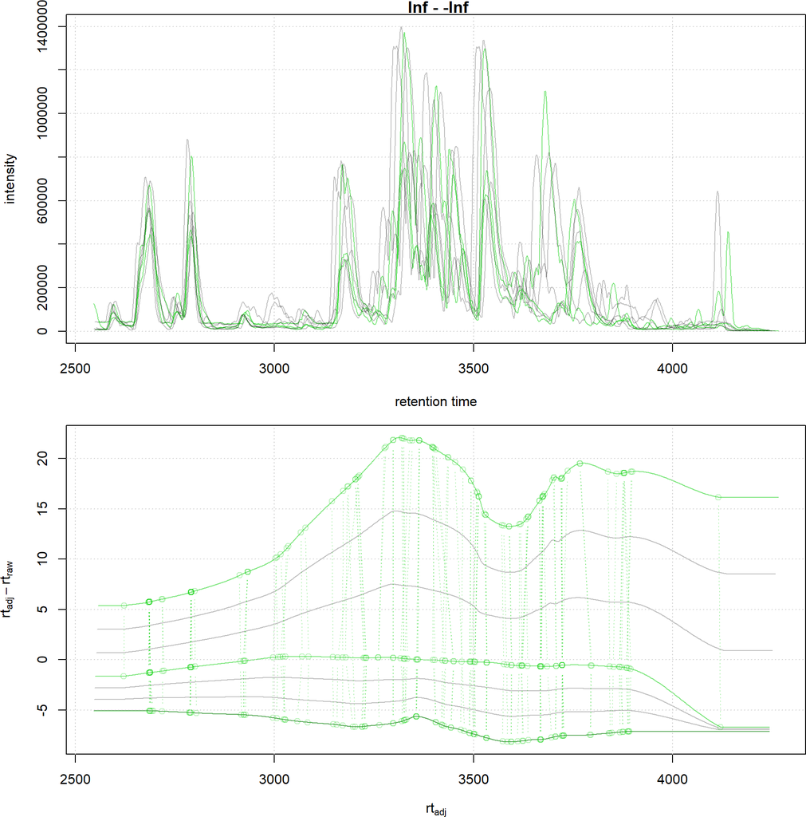

Figure 16: Subset-alignment results with option average  
Difference between adjusted and raw retention times along the retention time axis. Samples on which the alignment models were estimated are shown in green, study samples in grey.

```r
clrs <- rep("#00000040", 8)
clrs[sampleData(faahko)$sample_type == "QC"] <- c("#00ce0080")
par(mfrow = c(2, 1), mar = c(4, 4.5, 1, 0.5))
plot(chromatogram(faahko, aggregationFun = "max", chromPeaks = "none"),
     col = clrs)
grid()
plotAdjustedRtime(faahko, col = clrs, peakGroupsPch = 1,
                  peakGroupsCol = "#00ce0040")
grid()
```

Option `subsetAdjust = "previous"` would adjust the retention times of a non-subset sample based on a single subset sample (the previous), which results in most cases in the adjusted retention times of the non-subset sample being highly similar to those of the subset sample which was used for adjustment.

## 2.5 Correspondence

Correspondence is usually the final step in LC-MS data pre-processing in which data, presumably representing signal from the same originating ions, is matched across samples. As a result, chromatographic peaks from different samples with similar m/z and retention times get grouped into LC-MS *features*. The function to perform the correspondence in *xcms* is called `groupChromPeaks` that again supports different algorithms which can be selected and configured with a specific parameter object (see `?groupChromPeaks` for an overview). For our example we will use the *peak density* method [1] that, within small slices along the m/z dimension, combines chromatographic peaks depending on the density of these peaks along the retention time axis. To illustrate this, we *simulate* below the peak grouping for an m/z slice containing multiple chromatoghaphic peaks within each sample using the `plotChromPeakDensity` function and a `PeakDensityParam` object with parameter `minFraction = 0.4` (features are only defined if in at least 40% of samples a chromatographic peak was present) - parameter `sampleGroups` is used to define to which sample group each sample belongs.

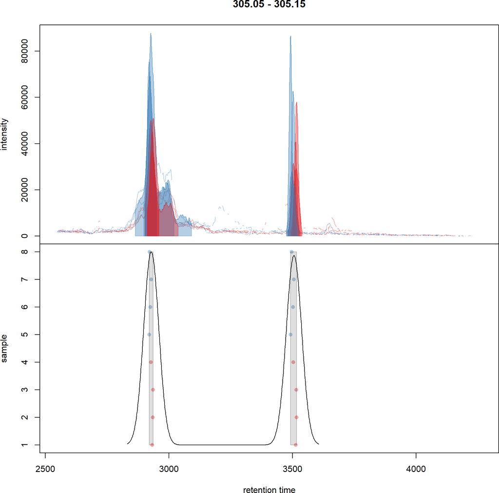

Figure 17: Example for peak density correspondence  
Upper panel: chromatogram for an mz slice with multiple chromatographic peaks. lower panel: identified chromatographic peaks at their retention time (x-axis) and index within samples of the experiments (y-axis) for different values of the bw parameter. The black line represents the peak density estimate. Grouping of peaks (based on the provided settings) is indicated by grey rectangles.

```r
## Define the mz slice.
mzr <- c(305.05, 305.15)

## Extract and plot the chromatograms
chr_mzr <- chromatogram(faahko, mz = mzr)
## Define the parameters for the peak density method
pdp <- PeakDensityParam(sampleGroups = sampleData(faahko)$sample_group,
                        minFraction = 0.4, bw = 30)
plotChromPeakDensity(chr_mzr, col = sample_colors, param = pdp,
                     peakBg = sample_colors[chromPeaks(chr_mzr)[, "sample"]],
                     peakCol = sample_colors[chromPeaks(chr_mzr)[, "sample"]],
                     peakPch = 16)
```

The upper panel in the plot shows the extracted ion chromatogram for each sample with the detected peaks highlighted. The retention times for the individual chromatographic peaks in each sample (y-axis being the index of the sample in the data set) are shown in the lower panel with the solid black line representing the density estimate for the distribution of detected peaks along the retention time. Parameter `bw` defines the *smoothness* of this estimation. The grey rectangles indicate which chromatographic peaks would be grouped into a feature (each grey rectangle thus representing one feature). This type of visualization is thus ideal to test, validate and optimize correspondence settings on manually defined m/z slices before applying them to the full data set. For the tested m/z slice the settings seemed to be OK and we are thus applying them to the full data set below. Especially the parameter `bw` will be very data set dependent (or more specifically LC-dependent) and should be adapted to each data set. See the [Metabolomics pre-processing with `xcms`](https://jorainer.github.io/metabolomics2018) tutorial for examples and more details.

```r
## Perform the correspondence
pdp <- PeakDensityParam(sampleGroups = sampleData(faahko)$sample_group,
                        minFraction = 0.4, bw = 30)
faahko <- groupChromPeaks(faahko, param = pdp)
```

Results from the correspondence analysis can be accessed with the `featureDefinitions` and `featureValues` function. The former returns a data frame with general information on each of the defined features, with each row being one feature and columns providing information on the median m/z and retention time as well as the indices of the chromatographic peaks assigned to the feature in column `"peakidx"`. Below we show the information on the first 6 features.

```r
featureDefinitions(faahko) |> head()
```

```
##       mzmed mzmin mzmax    rtmed    rtmin    rtmax npeaks KO WT      peakidx
## FT001 200.1 200.1 200.1 2902.177 2882.133 2922.222      2  2  0    458, 1161
## FT002 205.0 205.0 205.0 2789.457 2782.376 2795.823      8  4  4 44, 443,....
## FT003 206.0 206.0 206.0 2788.770 2780.807 2793.606      7  3  4 29, 430,....
## FT004 207.1 207.1 207.1 2718.476 2713.314 2726.487      7  4  3 16, 420,....
## FT005 233.0 233.0 233.1 3023.353 3014.971 3043.942      7  3  4 69, 959,....
## FT006 241.1 241.1 241.2 3680.200 3661.067 3695.533      8  3  4 276, 284....
##       ms_level
## FT001        1
## FT002        1
## FT003        1
## FT004        1
## FT005        1
## FT006        1
```

The `featureValues` function returns a `matrix` with rows being features and columns samples. The content of this matrix can be defined using the `value` argument which can be any column name in the `chromPeaks` matrix. With the default `value = "into"` a matrix with the integrated signal of the peaks corresponding to a feature in a sample are returned. This is then generally used as the intensity matrix for downstream analysis. Below we extract the intensities for the first 6 features.

```r
featureValues(faahko, value = "into") |> head()
```

```
##        ko15.CDF  ko16.CDF  ko21.CDF  ko22.CDF  wt15.CDF  wt16.CDF  wt21.CDF
## FT001        NA  506848.9        NA  169955.6        NA        NA        NA
## FT002 1924712.0 1757151.0 1383416.7 1180288.2 2129885.1 1634342.0 1623589.2
## FT003  213659.3  289500.7        NA  178285.7  253825.6  241844.4  240606.0
## FT004  349011.5  451863.7  343897.8  208002.8  364609.8  360908.9        NA
## FT005  286221.4        NA  164009.0  149097.6  255697.7  311296.8  366441.5
## FT006 1160580.5        NA  380970.3  588986.4 1286883.0 1739516.6  639755.3
##        wt22.CDF
## FT001        NA
## FT002 1354004.9
## FT003  185399.5
## FT004  221937.5
## FT005  271128.0
## FT006  508546.4
```

As we can see we have several missing values in this feature matrix. Missing values are reported if in one sample no chromatographic peak was detected in the m/z - rt region of the feature. This does however not necessarily mean that there is no signal for that specific ion in that sample. The chromatographic peak detection algorithm could also just have failed to identify any peak in that region, e.g. because the signal was too noisy or too low. Thus it is advisable to perform, after correspondence, also a gap-filling (see next section).

The performance of peak detection, alignment and correspondence should always be evaluated by inspecting extracted ion chromatograms e.g. of known compounds, internal standards or identified features in general. The `featureChromatograms` function allows to extract chromatograms for each feature present in `featureDefinitions`. The returned `MChromatograms` object contains an ion chromatogram for each feature (each row containing the data for one feature) and sample (each column representing containing data for one sample). Parameter `features` allows to define specific features for which the EIC should be returned. These can be specified with their index or their ID (i.e. their row name in the `featureDefinitions` data frame. If `features` is not defined, EICs are returned for **all** features in a data set, which can take also a considerable amount of time. Below we extract the chromatograms for the first 4 features.

```r
feature_chroms <- featureChromatograms(faahko, features = 1:4)

feature_chroms
```

```
## XChromatograms with 4 rows and 8 columns
##             ko15.CDF        ko16.CDF        ko21.CDF        ko22.CDF
##      <XChromatogram> <XChromatogram> <XChromatogram> <XChromatogram>
## [1,]        peaks: 0        peaks: 1        peaks: 0        peaks: 1
## [2,]        peaks: 1        peaks: 1        peaks: 1        peaks: 1
## [3,]        peaks: 1        peaks: 1        peaks: 0        peaks: 1
## [4,]        peaks: 1        peaks: 1        peaks: 1        peaks: 1
##             wt15.CDF        wt16.CDF        wt21.CDF        wt22.CDF
##      <XChromatogram> <XChromatogram> <XChromatogram> <XChromatogram>
## [1,]        peaks: 0        peaks: 0        peaks: 0        peaks: 0
## [2,]        peaks: 1        peaks: 1        peaks: 1        peaks: 1
## [3,]        peaks: 1        peaks: 1        peaks: 1        peaks: 1
## [4,]        peaks: 1        peaks: 1        peaks: 0        peaks: 1
## phenoData with 4 variables
## featureData with 4 variables
## - - - xcms preprocessing - - -
## Chromatographic peak detection:
##  method: centWave
## Correspondence:
##  method: chromatographic peak density
##  4 feature(s) identified.
```

And plot the extracted ion chromatograms. We again use the group color for each identified peak to fill the area.

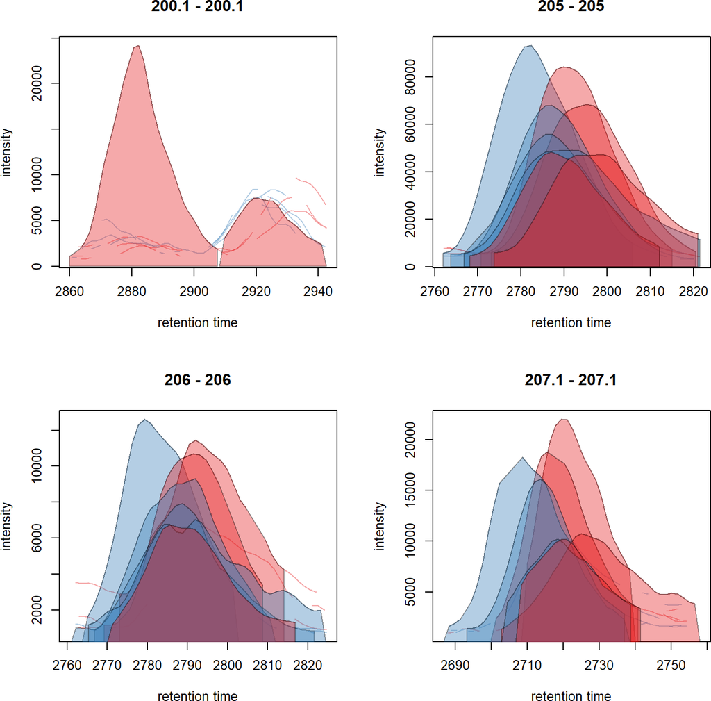

Figure 18: Extracted ion chromatograms for features 1 to 4

```r
plot(feature_chroms, col = sample_colors,
     peakBg = sample_colors[chromPeaks(feature_chroms)[, "sample"]])
```

To access the EICs of the second feature we can simply subset the `feature_chroms` object.

```r
eic_2 <- feature_chroms[2, ]
chromPeaks(eic_2)
```

```
##         mz mzmin mzmax       rt    rtmin    rtmax    into    intb  maxo sn
## CP0048 205   205   205 2791.365 2770.790 2815.117 1924712 1850331 84280 64
## CP0495 205   205   205 2795.185 2773.068 2820.462 1757151 1711473 68384 69
## CP1033 205   205   205 2795.823 2773.753 2821.042 1383417 1334570 47384 54
## CP1255 205   205   205 2788.583 2768.133 2812.172 1180288 1126958 48336 32
## CP1535 205   205   205 2782.376 2761.974 2805.911 2129885 2054677 93312 44
## CP1967 205   205   205 2787.149 2766.797 2812.193 1634342 1566379 67984 53
## CP2350 205   205   205 2790.332 2763.780 2821.562 1623589 1531573 49208 28
## CP2601 205   205   205 2787.209 2766.905 2812.192 1354005 1299188 55712 35
##        sample row column
## CP0048      1   1      1
## CP0495      2   1      2
## CP1033      3   1      3
## CP1255      4   1      4
## CP1535      5   1      5
## CP1967      6   1      6
## CP2350      7   1      7
## CP2601      8   1      8
```

## 2.6 Gap filling

Missing values in LC-MS data are in many cases the result of the chromatographic peak detection algorithm failing to identify peaks (because of noisy or low intensity signal). The aim of the gap filling step is to reduce the number of such missing values by integrating signals from the original data files for samples in which no chromatographic peak was found from the m/z - rt region where signal from the ion is expected. Gap filling can be performed in *xcms* with the `fillChromPeaks` function and a parameter object selecting and configuring the gap filling algorithm. The method of choice is `ChromPeakAreaParam` that integrates the signal (in samples in which no chromatographic peak was found for a feature) in the m/z - rt region that is defined based on the m/z and retention time ranges of all detected chromatographic peaks of that specific feature. The lower m/z limit of the area is defined as the lower quartile (25% quantile) of the `"mzmin"` values of all peaks of the feature, the upper m/z value as the upper quartile (75% quantile) of the `"mzmax"` values, the lower rt value as the lower quartile (25% quantile) of the `"rtmin"` and the upper rt value as the upper quartile (75% quantile) of the `"rtmax"` values. Below we perform this gap filling on our test data and extract the feature values for the first 6 features after gap filling. An `NA` is reported if no signal is measured at all for a specific sample.

```r
faahko <- fillChromPeaks(faahko, param = ChromPeakAreaParam())

featureValues(faahko, value = "into") |> head()
```

```
##        ko15.CDF  ko16.CDF  ko21.CDF  ko22.CDF  wt15.CDF  wt16.CDF  wt21.CDF
## FT001  135422.4  506848.9  111872.0  169955.6  210333.1  141880.3  233271.3
## FT002 1924712.0 1757151.0 1383416.7 1180288.2 2129885.1 1634342.0 1623589.2
## FT003  213659.3  289500.7  167516.7  178285.7  253825.6  241844.4  240606.0
## FT004  349011.5  451863.7  343897.8  208002.8  364609.8  360908.9  219142.3
## FT005  286221.4  286594.4  164009.0  149097.6  255697.7  311296.8  366441.5
## FT006 1160580.5 1145753.0  380970.3  588986.4 1286883.0 1739516.6  639755.3
##        wt22.CDF
## FT001  142254.8
## FT002 1354004.9
## FT003  185399.5
## FT004  221937.5
## FT005  271128.0
## FT006  508546.4
```

## 2.7 Final result

While we can continue using the *xcms* result set for further analysis (e.g. also for feature grouping with the *MsFeatures* package; see the LC-MS feature grouping vignette for details) we could also extract all results as a `SummarizedExperiment` object. This is the *standard* data container for Bioconductor defined in the *SummarizedExperiment* package and integration with other Bioconductor packages might thus be easier using that type of object. Below we use the `quantify` function to extract the *xcms* pre-processing results as such a `SummarizedExperiment` object. Internally, the `featureValues` function is used to generate the feature value matrix. We can pass any parameters from that function to the `quantify` call. Below we use `value = "into"` and `method = "sum"` to report the integrated peak signal as intensity and to sum these values in samples in which more than one chromatographic peak was assigned to a feature (for that option it is important to run `refineChromPeaks` like described above to merge overlapping peaks in each sample).

```r
library(SummarizedExperiment)
res <- quantify(faahko, value = "into", method = "sum")
res
```

```
## class: SummarizedExperiment
## dim: 351 8
## metadata(6): '' '' ... '' ''
## assays(1): raw
## rownames(351): FT001 FT002 ... FT350 FT351
## rowData names(10): mzmed mzmin ... WT ms_level
## colnames(8): ko15.CDF ko16.CDF ... wt21.CDF wt22.CDF
## colData names(4): sample_name sample_group spectraOrigin sample_type
```

The information from `featureDefinitions` is now stored in the `rowData` of this object. The `rowData` provides annotations and information for each **row** in the `SummarizedExperiment` (which in our case are the **features**).

```r
rowData(res)
```

```
## DataFrame with 351 rows and 10 columns
##           mzmed     mzmin     mzmax     rtmed     rtmin     rtmax    npeaks
##       <numeric> <numeric> <numeric> <numeric> <numeric> <numeric> <numeric>
## FT001     200.1     200.1     200.1   2902.18   2882.13   2922.22         2
## FT002     205.0     205.0     205.0   2789.46   2782.38   2795.82         8
## FT003     206.0     206.0     206.0   2788.77   2780.81   2793.61         7
## FT004     207.1     207.1     207.1   2718.48   2713.31   2726.49         7
## FT005     233.0     233.0     233.1   3023.35   3014.97   3043.94         7
## ...         ...       ...       ...       ...       ...       ...       ...
## FT347    595.25     595.2     595.3   3010.39   2992.58   3014.16         6
## FT348    596.20     596.2     596.2   2997.60   2992.58   3002.62         2
## FT349    596.30     596.3     596.3   3818.98   3811.68   3835.78         4
## FT350    597.40     597.4     597.4   3821.10   3817.96   3825.14         3
## FT351    599.30     599.3     599.3   4070.45   4042.10   4123.52         3
##              KO        WT  ms_level
##       <numeric> <numeric> <integer>
## FT001         2         0         1
## FT002         4         4         1
## FT003         3         4         1
## FT004         4         3         1
## FT005         3         4         1
## ...         ...       ...       ...
## FT347         2         3         1
## FT348         0         2         1
## FT349         2         2         1
## FT350         1         2         1
## FT351         1         2         1
```

Annotations for **columns** (in our case **samples**) are stored as `colData`. In this data frame each row contains annotations for one sample (and hence one column in the feature values matrix).

```r
colData(res)
```

```
## DataFrame with 8 rows and 4 columns
##          sample_name sample_group  spectraOrigin sample_type
##          <character>  <character>    <character> <character>
## ko15.CDF        ko15           KO F:\\biocbui...          QC
## ko16.CDF        ko16           KO F:\\biocbui...       study
## ko21.CDF        ko21           KO F:\\biocbui...       study
## ko22.CDF        ko22           KO F:\\biocbui...          QC
## wt15.CDF        wt15           WT F:\\biocbui...       study
## wt16.CDF        wt16           WT F:\\biocbui...       study
## wt21.CDF        wt21           WT F:\\biocbui...          QC
## wt22.CDF        wt22           WT F:\\biocbui...       study
```

Finally, the feature matrix is stored as an `assay` within the object. Note that a `SummarizedExperiment` can have multiple assays which have to be numeric matrices with the number of rows and columns matching the number of features and samples, respectively. Below we list the names of the available assays.

```r
assayNames(res)
```

```
## [1] "raw"
```

And we can access the actual data using the `assay` function, optionally also providing the name of the assay we want to access. Below we show the first 6 lines of that matrix.

```r
assay(res) |> head()
```

```
##        ko15.CDF  ko16.CDF  ko21.CDF  ko22.CDF  wt15.CDF  wt16.CDF  wt21.CDF
## FT001  135422.4  506848.9  111872.0  169955.6  210333.1  141880.3  233271.3
## FT002 1924712.0 1757151.0 1383416.7 1180288.2 2129885.1 1634342.0 1623589.2
## FT003  213659.3  289500.7  167516.7  178285.7  253825.6  241844.4  240606.0
## FT004  349011.5  451863.7  343897.8  208002.8  364609.8  360908.9  219142.3
## FT005  286221.4  286594.4  164009.0  149097.6  255697.7  311296.8  366441.5
## FT006 1923307.8 1145753.0  380970.3  588986.4 1286883.0 1739516.6  639755.3
##        wt22.CDF
## FT001  142254.8
## FT002 1354004.9
## FT003  185399.5
## FT004  221937.5
## FT005  271128.0
## FT006  508546.4
```

Since a `SummarizedExperiment` supports multiple assays, we in addition add also the feature value matrix **without** filled-in values (i.e. feature intensities that were added by the gap filling step).

```r
assays(res)$raw_nofill <- featureValues(faahko, filled = FALSE, method = "sum")
```

With that we have now two assays in our result object.

```r
assayNames(res)
```

```
## [1] "raw"        "raw_nofill"
```

And we can extract the feature values without gap-filling:

```r
assay(res, "raw_nofill") |> head()
```

```
##        ko15.CDF  ko16.CDF  ko21.CDF  ko22.CDF  wt15.CDF  wt16.CDF  wt21.CDF
## FT001        NA  506848.9        NA  169955.6        NA        NA        NA
## FT002 1924712.0 1757151.0 1383416.7 1180288.2 2129885.1 1634342.0 1623589.2
## FT003  213659.3  289500.7        NA  178285.7  253825.6  241844.4  240606.0
## FT004  349011.5  451863.7  343897.8  208002.8  364609.8  360908.9        NA
## FT005  286221.4        NA  164009.0  149097.6  255697.7  311296.8  366441.5
## FT006 1923307.8        NA  380970.3  588986.4 1286883.0 1739516.6  639755.3
##        wt22.CDF
## FT001        NA
## FT002 1354004.9
## FT003  185399.5
## FT004  221937.5
## FT005  271128.0
## FT006  508546.4
```

Finally, a history of the full processing with *xcms* is available as `metadata` in the `SummarizedExperiment`.

```r
metadata(res)
```

```
## [[1]]
## Object of class "XProcessHistory"
##  type: Peak detection
##  date: Tue Jan 16 23:00:20 2024
##  info:
##  fileIndex: 1,2,3,4,5,6,7,8
##  Parameter class: CentWaveParam
##  MS level(s) 1
##
## [[2]]
## Object of class "XProcessHistory"
##  type: Peak refinement
##  date: Tue Jan 16 23:00:22 2024
##  info:
##  fileIndex: 1,2,3,4,5,6,7,8
##  Parameter class: MergeNeighboringPeaksParam
##  MS level(s) 1
##
## [[3]]
## Object of class "XProcessHistory"
##  type: Peak grouping
##  date: Tue Jan 16 23:00:44 2024
##  info:
##  fileIndex: 1,2,3,4,5,6,7,8
##  Parameter class: PeakDensityParam
##  MS level(s) 1
##
## [[4]]
## Object of class "XProcessHistory"
##  type: Retention time correction
##  date: Tue Jan 16 23:00:45 2024
##  info:
##  fileIndex: 1,2,3,4,5,6,7,8
##  Parameter class: PeakGroupsParam
##  MS level(s) 1
##
## [[5]]
## Object of class "XProcessHistory"
##  type: Peak grouping
##  date: Tue Jan 16 23:01:01 2024
##  info:
##  fileIndex: 1,2,3,4,5,6,7,8
##  Parameter class: PeakDensityParam
##  MS level(s) 1
##
## [[6]]
## Object of class "XProcessHistory"
##  type: Missing peak filling
##  date: Tue Jan 16 23:01:06 2024
##  info:
##  fileIndex: 1,2,3,4,5,6,7,8
##  Parameter class: ChromPeakAreaParam
##  MS level(s) 1
```

This same information can also be extracted from the *xcms* result object using the `processHistory` function. Below we extract the information for the first processing step.

```r
processHistory(faahko)[[1]]
```

```
## Object of class "XProcessHistory"
##  type: Peak detection
##  date: Tue Jan 16 23:00:20 2024
##  info:
##  fileIndex: 1,2,3,4,5,6,7,8
##  Parameter class: CentWaveParam
##  MS level(s) 1
```

These processing steps contain also the individual parameter objects used for the analysis, hence allowing to exactly reproduce the analysis.

```r
processHistory(faahko)[[1]] |> processParam()
```

```
## Object of class:  CentWaveParam
##  Parameters:
##  - ppm: [1] 25
##  - peakwidth: [1] 20 80
##  - snthresh: [1] 10
##  - prefilter: [1]    6 5000
##  - mzCenterFun: [1] "wMean"
##  - integrate: [1] 1
##  - mzdiff: [1] -0.001
##  - fitgauss: [1] FALSE
##  - noise: [1] 5000
##  - verboseColumns: [1] FALSE
##  - roiList: list()
##  - firstBaselineCheck: [1] TRUE
##  - roiScales: numeric(0)
##  - extendLengthMSW: [1] FALSE
```

At last we perform also a principal component analysis to evaluate the grouping of the samples in this experiment. Note that we did not perform any data normalization hence the grouping might (and will) also be influenced by technical biases.

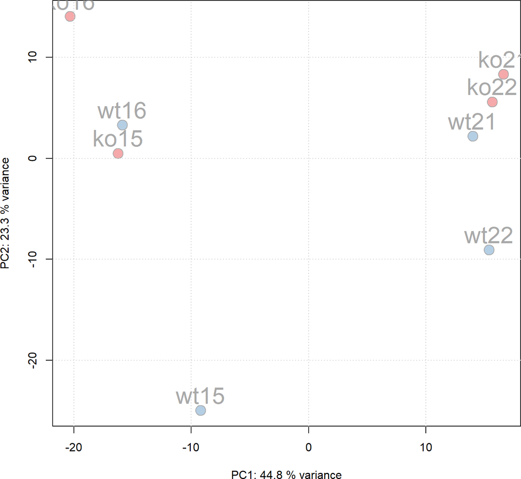

Figure 19: PCA for the faahKO data set, un-normalized intensities

```r
## Extract the features and log2 transform them
ft_ints <- log2(assay(res, "raw"))

## Perform the PCA omitting all features with an NA in any of the
## samples. Also, the intensities are mean centered.
pc <- prcomp(t(na.omit(ft_ints)), center = TRUE)

## Plot the PCA
pcSummary <- summary(pc)
plot(pc$x[, 1], pc$x[,2], pch = 21, main = "",
     xlab = paste0("PC1: ", format(pcSummary$importance[2, 1] * 100,
                                   digits = 3), " % variance"),
     ylab = paste0("PC2: ", format(pcSummary$importance[2, 2] * 100,
                                   digits = 3), " % variance"),
     col = "darkgrey", bg = sample_colors, cex = 2)
grid()
text(pc$x[, 1], pc$x[,2], labels = res$sample_name, col = "darkgrey",
     pos = 3, cex = 2)
```

We can see the expected separation between the KO and WT samples on PC2. On PC1 samples separate based on their ID, samples with an ID <= 18 from samples with an ID > 18. This separation might be caused by a technical bias (e.g. measurements performed on different days/weeks) or due to biological properties of the mice analyzed (sex, age, litter mates etc).

# 3 Further data processing and analysis

Normalizing features’ signal intensities is required, but at present not (yet) supported in `xcms` (some methods might be added in near future). It is advised to use the `SummarizedExperiment` returned by the `quantify` method for any further data processing, as this type of object stores feature definitions, sample annotations as well as feature abundances in the same object. For the identification of e.g. features with significant different intensities/abundances it is suggested to use functionality provided in other R packages, such as Bioconductor’s excellent `limma` package.

# 4 Additional details and notes

## 4.1 Subsetting and filtering

*xcms* result objects can be subset/filtered by sample using the `[` method or one of the `filter*` functions (although the `XcmsExperiment` supports at present only few selected filter functions). In some cases filtering can remove pre-processing results, but most filter functions support parameters `keepFeatures` and `keepAdjustedRtime` that can be set to `TRUE` to avoid their removal.

## 4.2 Parallel processing

Most functions in *xcms* support parallel processing, which is enabled by default and is performed, for most operations, on a per-file basis. Parallel processing is handled and configured by the `BiocParallel` Bioconductor package and can be globally defined for an R session. Note that, while all data objects are designed to have a low memory footprint by loading only peak data into memory when needed, parallel processing will increase this demand: in general, the full data for as many files as there are parallel processes are loaded into memory. This needs also to be considered, when the number of parallel processes is defined.

Unix-based systems (Linux, macOS) support `multicore`-based parallel processing. To configure it globally we `register` the parameter class. Note also that `bpstart` is used below to initialize the parallel processes.

```r
register(bpstart(MulticoreParam(2)))
```

Windows supports only socket-based parallel processing:

```r
register(bpstart(SnowParam(2)))
```

## 4.3 Main differences to the `MSnbase`-based xcms version 3

- `Spectra` is used as the main container for the (raw) MS data. Thus changing backends is supported at any stage of the analysis (e.g. to load all data into memory or to load data from remote databases).

# 5 Additional documentation resources

Some of the documentations listed here are still based on xcms version 3 but will be subsequently updated.

- [Metabolomics pre-processing with `xcms`](https://jorainer.github.io/metabolomics2018): more detailed description of the pre-processing of LC-MS data with *xcms*.
- MetaboAnnotationTutorials: examples for annotation of metabolomics data from [3].
- [2]: describes the concept of the *on-disk* data modes used also in *xcms*.
- SpectraTutorials: tutorials describing the *Spectra* package and its functionality.

# 6 Session information

# References

1. Smith CA, Want EJ, O’Maille G, Abagyan R, Siuzdak G: **XCMS: processing mass spectrometry data for metabolite profiling using nonlinear peak alignment, matching, and identification.** *Analytical chemistry* 2006, **78**:779–787.

2. Gatto L, Gibb S, Rainer J: **MSnbase, Efficient and Elegant R-Based Processing and Visualization of Raw Mass Spectrometry Data**. *Journal of Proteome Research* 2020.

3. Rainer J, Vicini A, Salzer L, Stanstrup J, Badia JM, Neumann S, Stravs MA, Verri Hernandes V, Gatto L, Gibb S, Witting M: **A Modular and Expandable Ecosystem for Metabolomics Data Annotation in R**. *Metabolites* 2022, **12**:173.

4. Saghatelian A, Trauger SA, Want EJ, Hawkins EG, Siuzdak G, Cravatt BF: **Assignment of endogenous substrates to enzymes by global metabolite profiling**. *Biochemistry* 2004, **43**:14332–9.

5. Tautenhahn R, Böttcher C, Neumann S: **Highly sensitive feature detection for high resolution LC/MS.** *BMC Bioinformatics* 2008, **9**:504.

6. Smith R, Ventura D, Prince JT: **LC-MS alignment in theory and practice: a comprehensive algorithmic review.** *Briefings in bioinformatics* 2013, **16**:bbt080–117.

7. Prince JT, Marcotte EM: **Chromatographic alignment of ESI-LC-MS proteomics data sets by ordered bijective interpolated warping.** *Analytical chemistry* 2006, **78**:6140–6152.